# Part_II_slide_deck slides

## Part II - (Effect of Prosper score and loan amount on Borrowers APR)

## by (ThankGod Onmeje)

## Investigation Overview

> In this exploration I want to demostrate that there is a strong negative corrolation between the BorrowersAPR and the Proser Score ie. the higher the prosper score the lower the APR. Also that the higher the loan amount the lower the borrowersAPR showing a negative corrolation between the two

## Dataset Overview

> This data set contains 113,937 loans with 81 variables on each loan, including loan amount, borrower rate (or interest rate), current loan status, borrower income, and many others. the loans were given by proser loan company

## Visualization 1- Destibution of Borrowers APR

> The Borrowers APR seem to be multimodal with a high spike around 0.37. The values typically ranges from o.05-0.43 which is a percentage of the annual rate charged

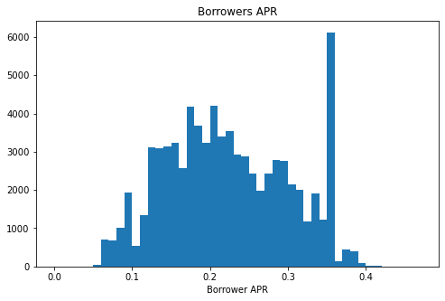

## (Visualization 2- Destribution of Prosper score)

> The Prospers score is a custom risk score build using historical prosper data. It ranges from 1-11 with 11 being the best or lowest risk socre. The most common scores are 4,6,and 8 and the least common is 1

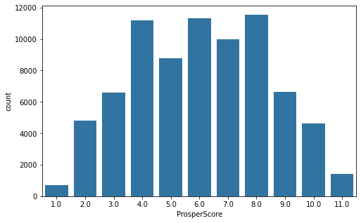

## (Visualization 3- Destribution of loan amount)

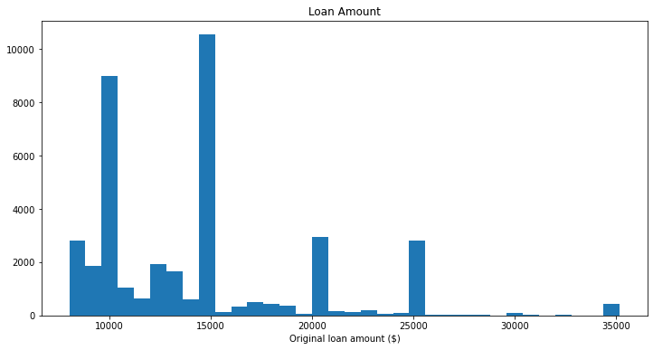

## Borrowers APR vs. Prosper score

> There is a negative corrolation between the prosper score and the APR. Borrowers with better scores have lesser APR

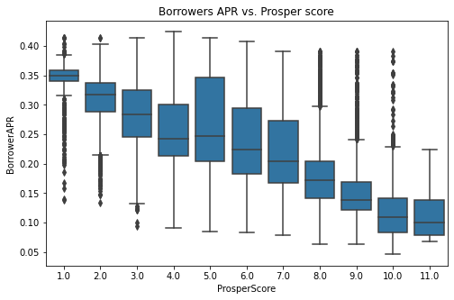

## Borrowers APR vs. Loan Amount

> There is also a negative reationship between the loan amount and the APR. Hence The more the loan amount the lower the APR. this could indicate a strategy to encourage borrowers to borrow more.

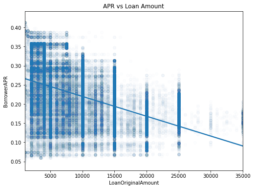